# Compito di Statistica

Scrivere in stampatello

| COGNOME | $\LARGE\square$ | $\LARGE\square$ | $\LARGE\square$ | $\LARGE\square$ | $\LARGE\square$ | $\LARGE\square$ | $\LARGE\square$ | $\LARGE\square$ | $\LARGE\square$ | $\LARGE\square$ | $\LARGE\square$ | $\LARGE\square$ | $\LARGE\square$ | $\LARGE\square$ | $\LARGE\square$ | $\LARGE\square$ | $\LARGE\square$ | $\LARGE\square$ | $\LARGE\square$ | $\LARGE\square$ |
| --- | --- | --- | --- | --- | --- | --- | --- | --- | --- | --- | --- | --- | --- | --- | --- | --- | --- | --- | --- | --- |
| NOME | $\LARGE\square$ | $\LARGE\square$ | $\LARGE\square$ | $\LARGE\square$ | $\LARGE\square$ | $\LARGE\square$ | $\LARGE\square$ | $\LARGE\square$ | $\LARGE\square$ | $\LARGE\square$ | $\LARGE\square$ | $\LARGE\square$ | $\LARGE\square$ | $\LARGE\square$ | $\LARGE\square$ | $\LARGE\square$ | $\LARGE\square$ | $\LARGE\square$ | $\LARGE\square$ | $\LARGE\square$ |
| Matricola | $\LARGE\square$ | $\LARGE\square$ | $\LARGE\square$ | $\LARGE\square$ | $\LARGE\square$ | $\LARGE\square$ | $\LARGE\square$ | $\LARGE\square$ | $\LARGE\square$ | $\LARGE\square$ | $\LARGE\square$ | $\LARGE\square$ | $\LARGE\square$ | $\LARGE\square$ | $\LARGE\square$ | $\LARGE\square$ | $\LARGE\square$ | $\LARGE\square$ | $\LARGE\square$ | $\LARGE\square$ |
| CDL | $\LARGE\square$ | $\LARGE\square$ | $\LARGE\square$ | $\LARGE\square$ | $\LARGE\square$ |  |  |  |  |  |  |  |  |  |  |  |  |  |  |  |

### Esercizio 1

Su un campione di $350$ aziende è stato rilevato il costo annuo in gas metano (espresso in migliaia di euro). Qui di seguito l’istogramma di densità:

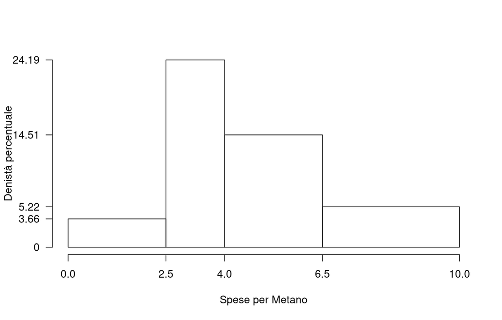

| $[\text{x}_j,$ | $\text{x}_{j+1})$ | $h_j$ |
| --- | --- | --- |
| 0.0 | 2.5 | 3.657 |
| 2.5 | 4.0 | 24.191 |
| 4.0 | 6.5 | 14.514 |
| 6.5 | 10.0 | 5.224 |

1.a (**Punti 14 su 102 (4.12 su 30)**) Calcolare il valore approssimato della mediana.

Per individuare la mediana dobbiamo costruire le basi:
$$b_j=x_{j+1}-x_{j}$$
le frequenze relative,
$$f_j=h_j\cdot b_j,$$
le cumulate
$$F_j=f_1+...+f_j$$
ricostruire la tabella

| $[\text{x}_j,$ | $\text{x}_{j+1})$ | $h_j$ | $b_j$ | $f_j$ | $F_j$ |
| --- | --- | --- | --- | --- | --- |
| 0.0 | 2.5 | 3.657 | 2.5 | 0.0914 | 0.0914 |
| 2.5 | 4.0 | 24.191 | 1.5 | 0.3629 | 0.4543 |
| 4.0 | 6.5 | 14.514 | 2.5 | 0.3629 | 0.8171 |
| 6.5 | 10.0 | 5.224 | 3.5 | 0.1829 | 1.0000 |
|  |  |  | 10.0 | 1.0000 |  |

e quindi:

$$\begin{eqnarray*}
p &=& 0.5, \text{essendo }F_{3}=0.8171 >0.5 \Rightarrow
j_{0.5}=3\\
x_{0.5} &=& x_{\text{inf};3} + \frac{ {0.5} - F_{2}} {f_{3}}
\cdot b_{3} \\
&=& 4 + \frac {{0.5} - 0.4543} {0.3629} \cdot
2.5 \\
&=& 4.315
\end{eqnarray*}$$

1.b (**Punti 3 su 102 (0.88 su 30)**) Che relazione dobbiamo aspettarci tra media e mediana?

1.c (**Punti 2 su 102 (0.59 su 30)**) La varianza dei dati è pari a $\sigma^2=4.8382$. Nell’ipotesi che i costi per metano aumentassero del 10%, quanto varrebbe la varianza?

Si tratta di una trasformazione lineare
$$Y = 1.1\cdot X$$
e quindi
$$\sigma_Y^2=(1.1)^2\sigma_X^2=5.8542.$$

### Esercizio 2

Siano $X\sim \text{Pois}(1.5)$ e sia $Y\sim \text{Pois}(1.5)$, $X$ e $Y$ indipendenti. Posto $A=\{X<2\}$ e $B=\{Y\ge 2\}$

2.a (**Punti 14 su 102 (4.12 su 30)**) Quanto vale $P(A\cup B)$?

$$\begin{eqnarray*}
P(A) &=& P(X=0)+P(X=1)\\
&=& \frac{1.5^0}{0!}e^{-1.5}+\frac{1.5^1}{1!}e^{-1.5}\\
&=& 0.5578\\
P(B) &=& 1-P(A)\\
&=&0.4422\\
P(A\cup B) &=& P(A)+P(B)-P(A\cap B)\\
&=& 0.7533
\end{eqnarray*}$$

2.b (**Punti 3 su 102 (0.88 su 30)**) Si estrae 6 volte da $X\sim \text{Pois}(1.5)$, posto $A=\{X<2\}$, quale è la probabilità che $A$ si avveri 3 volte su 6?

$$\begin{eqnarray*}
P(A) &=& P(X=0)+P(X=1)\\
&=& \frac{1.5^0}{0!}e^{-1.5}+\frac{1.5^1}{1!}e^{-1.5}\\
&=& 0.2231+0.3347\\
&=& 0.5578\\
P(\text{3 successi su 6}) &=&
\binom{6}{3}0.5578^3(1-0.5578)^{6-3}\\
&=&0.3001
\end{eqnarray*}$$

2.c (**Punti 2 su 102 (0.59 su 30)**) Se $X$ è una VC con valore atteso $E(X)=0.5$ e $V(X)=1.2$, posto $Y=X^2$ è vero che $E(Y)=E^2(X)$?

### Esercizio 3

(**Punti 14 su 102 (4.12 su 30)**) Una catena di montaggio a ciclo continuo produce ogni giorno un numero di pezzi variabile, con una media pari a $\mu=1.3$ mila pezzi al giorno e una varianza di $\sigma^2=8.1$.

Calcolare la probabilità che la media annuale ($n=365$) sia inferiore a 1.2 (mila) pezzi prodotti.

**Teorema del Limite Centrale (media VC qualunque)**

Siano $X_1$,…,$X_n$, $n=365$ VC IID, tc $E(X_i)=\mu=1.3$ e $V(X_i)=\sigma^2=8.1,\forall i$, posto:
$$\bar X=\frac{S_n}n =\frac{X_1 + ... + X_n}n$$
allora:
$$\begin{eqnarray*}
\bar X & \mathop{\sim}\limits_{a}& N(\mu,\sigma^2/n) \\
&\sim & N\left(1.3,\frac{8.1}{365}\right) \\
&\sim & N(1.3,0.02219)
\end{eqnarray*}$$

$$\begin{eqnarray*}
P(\bar X < 1.2)
&=& P\left( \frac {\bar X - \mu}{\sqrt{\sigma^2/n}} <
\frac {1.2 - 1.3}{\sqrt{0.0222}} \right) \\
&=& P\left( Z < -0.67\right) \\
&=& 1-\Phi( 0.67 ) \\ &=& 0.2514
\end{eqnarray*}$$

### Esercizio 4

4.a (**Punti 3 su 102 (0.88 su 30)**) Siano $\hat \mu$ e $\hat\sigma^2$ gli stimatori di massima verosimiglianza di $\mu$ e $\sigma^2$ del modello di Normale.
$$\begin{eqnarray*}
\hat\mu &=& \frac 1n\sum_{i=1}^nx_i \qquad \hat\sigma^2
= \frac 1n\sum_{i=1}^n(x_i-\hat\mu)^2\\
\end{eqnarray*}$$
Come si distribuisce $\hat\mu$?

4.b (**Punti 3 su 102 (0.88 su 30)**) Sia $h$ uno stimatore per $\theta$ tale che
$$V(h)=\frac\theta
{\sqrt{n}};~~~~E(h)=\theta\frac{n+2}{n}$$
di quali proprietà gode $h$?

4.c (**Punti 3 su 102 (0.88 su 30)**) Definire il p-value e descrivere la sua interpretazione.

4.d (**Punti 3 su 102 (0.88 su 30)**) Se un test è significativo al 5% può essere significativo all’1%? (scegliere la risposta tra: *mai*, *non sempre* oppure *sempre* e motivare la risposta)

### Esercizio 5

Su un campione di $n=15$ abitanti del quartiere *Q* è stato chiesto di fornire un punteggio da 0 a 100 per esprimere quanto si sarebbe soddisfatti dall’introduzione di corsie preferenziali per i mezzi pubblici. Lo studio ha riportato una media pari a $76.3$ e una deviazione standard pari a $3.5$

5.a (**Punti 4 su 102 (1.18 su 30)**) Costruire un intervallo di confidenza la 99% per $\mu$ il punteggio medio che le persone del quartiere *Q* esprimono riguardo alle corsie preferenziali.

$$S =\sqrt{\frac {n}{n-1}}\cdot\hat\sigma =
\sqrt{\frac { 15 }{ 14 }}\cdot 3.5 = 3.6228$$
$$\begin{eqnarray*}
Idc: & & \hat\mu \pm t_{n-1;\alpha/2} \times
\frac{S}{\sqrt{n}} \\
& & 76.3 \pm 2.977 \times \frac{ 3.6228 }{\sqrt{ 15 }}
\\
& & 76.3 \pm 2.977 \times 0.9354 \\
& & [ 73.52 , 79.08 ]
\end{eqnarray*}$$

5.b (**Punti 10 su 102 (2.94 su 30)**) Un’indagine molto più ampia condotta su tutta la città ha mostrato che il punteggio medio è pari a 66.3 con un deviazione standard pari a 3.3 .

Testare al 5% l’ipotesi che nel quartiere *Q* il punteggio medio sia uguale a quello cittadino contro l’alternativa che sia maggiore.

$\fbox{A}$ FORMULAZIONE DELLE IPOTESI
$$\begin{cases}
H_0:\mu=\mu_0=66.3\text{}\\
H_1:\mu> \mu_0=66.3\text{}
\end{cases}$$

$\fbox{B}$ SCELTA E CALCOLO STATISTICA-TEST, $Z$ $\sigma^{2}$ di $\cal{P}$ è nota: $\Rightarrow$ z-Test.
$$\begin{eqnarray*}
\frac{\hat\mu - \mu_{0}} {\sigma/\sqrt{n}}&\sim&N(0,1)\\
z_{\text{obs}}
&=& \frac{ (76.3- 66.3)} {3.3/\sqrt{15}}
= 11.7363\, .
\end{eqnarray*}$$

$\fbox{C}$ DECISIONE Dalle tavole si ha $z_{0.05} = 1.6449$.
$$z_{\text{obs}} = 11.7363 > z_{0.05} =
1.6449$$

CONCLUSIONE: i dati **non** sono coerenti con $H_{0}$ al LdS del 5%

**Graficamente**

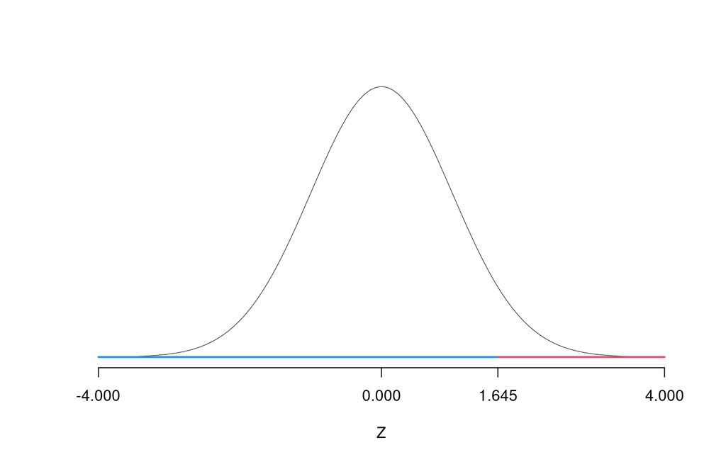

Il $p_{\text{value}}$ è
$$P(Z>z_{\text{obs}})=P(Z> 11.74 )=
0$$

### Esercizio 6

Sono stati analizzati 5 comuni della provincia di Bologna e su ogni comune è stato rilevato il PIL pro capite del comune $X$, espresso in decine di migliaia di euro e un valore di percezione di qualità della vita $Y$ (espresso su opportuna scala).

Qui di seguito i dati

|  | A | B | C | D | E |
| --- | --- | --- | --- | --- | --- |
| $x_i$ | 0.4 | 1.0 | 1.3 | 2.7 | 3.1 |
| $y_i$ | 3.2 | 6.8 | 5.0 | 6.9 | 6.3 |

6.a (**Punti 14 su 102 (4.12 su 30)**) Calcolare il residuo del comune B nel modello di regressione dove $Y$ viene spiegata da $X$.

| $i$ | $x_i$ | $y_i$ | $x_i^2$ | $y_i^2$ | $x_i\cdot y_i$ |
| --- | --- | --- | --- | --- | --- |
| 1 | 0.4 | 3.20 | 0.16 | 10.24 | 1.28 |
| 2 | 1.0 | 6.80 | 1.00 | 46.24 | 6.80 |
| 3 | 1.3 | 5.00 | 1.69 | 25.00 | 6.50 |
| 4 | 2.7 | 6.90 | 7.29 | 47.61 | 18.63 |
| 5 | 3.1 | 6.30 | 9.61 | 39.69 | 19.53 |
| Totale | 8.5 | 28.20 | 19.75 | 168.78 | 52.74 |
| Totale/n | 1.7 | 5.64 | 3.95 | 33.76 | 10.55 |

$$\begin{eqnarray*}
\bar x &=&\frac 1 n\sum_{i=1}^n x_i = \frac {1}{5} 8.5= 1.7\\
\bar y &=&\frac 1 n\sum_{i=1}^n y_i = \frac {1}{5} 28.2= 5.64\\
\hat\sigma_X^2&=&\frac 1 n\sum_{i=1}^n x_i^2-\bar x^2=\frac
{1}{5} 19.75 -1.7^2=1.06\\
\hat\sigma_Y^2&=&\frac 1 n\sum_{i=1}^n y_i^2-\bar y^2=\frac
{1}{5} 168.78 -5.64^2=1.9464\\
\text{cov}(X,Y)&=&\frac 1 n\sum_{i=1}^n x_i~y_i-\bar x\bar
y=\frac {1}{5} 52.74-1.7\cdot5.64=0.96\\
\hat\beta_1 &=& \frac{\text{cov}(X,Y)}{\hat\sigma_X^2} \\
&=& \frac{0.96}{1.06} = 0.9057\\
\hat\beta_0 &=& \bar y - \hat\beta_1 \bar x\\
&=& 5.64-0.9057\times 1.7=4.1004
\end{eqnarray*}$$

$$\begin{eqnarray*}
\hat y_i &=&\hat\beta_0+\hat\beta_1 x_i=\\
&=& 4.1 + 0.9057 \times 1 = 5.006 \\
\hat \varepsilon_i &=& y_i-\hat y_i\\
&=& 6.8 - 5.006 = 1.794
\end{eqnarray*}$$

6.b (**Punti 3 su 102 (0.88 su 30)**) Scrivere la scomposizione della varianza del modello di regressione e calcolare la Total Sum of Squares (TSS), la Explained Sum of Squares (ESS) e la Residual Sum of Squares (RSS) dei dati analizzati sopra.

$$\begin{eqnarray*}
TSS &=& n\hat\sigma^2_Y\\
&=& 5 \times 1.946 \\
&=& 9.732 \\
ESS &=& R^2\cdot TSS\\
&=& 0.4467 \cdot 9.732 \\
&=& 4.347 \\
RSS &=& (1-R^2)\cdot TSS\\
&=& (1- 0.4467 )\cdot 9.732 \\
&=& 5.385 \\
TSS &=& RSS+TSS \\ 9.732 &=& 4.347 + 5.385
\end{eqnarray*}$$

6.c (**Punti 3 su 102 (0.88 su 30)**) Interpretare il parametro di regressione $\hat\beta_1$.

6.d (**Punti 2 su 102 (0.59 su 30)**) Descrivere la differenza tra punti di leva e punti influenti.

6.e (**Punti 2 su 102 (0.59 su 30)**) Gli stimatori $\hat\beta_0$ e $\hat\beta_1$ dei minimi quadrati per $\beta_0$ e $\beta_1$ sono corretti?